# Multi traj RAPToR

Baptiste Rousseau

2023-01-15

```r
library(Biobase)
library(dplyr)
library(GEOquery)
library(ica)
library(limma)
library(RAPToR)
library(Seurat)
library(slingshot)
library(scales)
library(tradeSeq)
library(viridis)
library(wormRef)

source("ale.R")
source("multige_im.R")
source("utils.R")
```

Load data and keep only neurons lineages.

```r
dspacker <- readRDS("./data/eset_packer.rds")
dspacker$lineage2 <- substr(dspacker$lineage, 1, 2) # make 2 char lineage

# select neurons lineages ASE, ASJ and AUA
csel <- grepl(pattern = "ASE|ASJ|AUA", dspacker$cell.subtype)
table(dspacker$cell.subtype[csel], dspacker$embryo.time.bin[csel])
```

```
##
##                          < 100 100-130 130-170 170-210 210-270 270-330 330-390
##   ASE                        0       0       0       0       0       0      36
##   ASE_parent                 0       0       0       0       0      99      50
##   ASJ                        0       0       0       0       0       0      51
##   AUA                        0       0       0       0       0       0      37
##   Neuroblast_ASE_ASJ_AUA     0       0       0      14      89       0       0
##   Neuroblast_ASJ_AUA         0       0       0       0       0      89      34
##
##                          390-450 450-510 510-580 580-650 > 650
##   ASE                         77      68      15      33    53
##   ASE_parent                   0       0       0       0     0
##   ASJ                         77      71      30      38    53
##   AUA                         45      27      33      12     0
##   Neuroblast_ASE_ASJ_AUA       0       0       0       0     0
##   Neuroblast_ASJ_AUA           0       0       0       0     0
```

```r
pX <- exprs(dspacker) # extract counts
```

# Preprocessing data

We remove non/low-expressed genes and quantile-normalize the expression data, as well as apply a log(X+1) transformation. We then filter out poor quality samples using correlation with other samples.

```r
table(rowSums(pX) < 10) # filter low-expressed genes (also to lighten the data)
```

```
##
## FALSE  TRUE
## 17133  3089
```

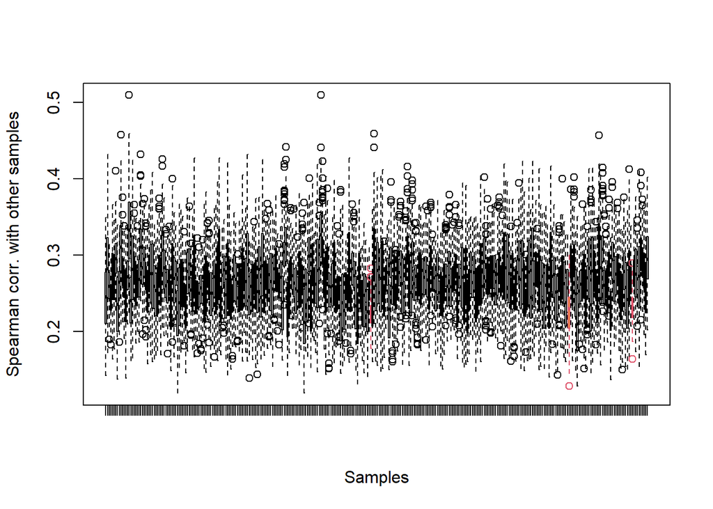

```r
# select annotated cells from one batch
sel_cells <- dspacker$batch == "Waterston_400_minutes" & dspacker$lineage != "unannotated" & grepl(pattern = "ASE|ASJ|AUA", dspacker$cell.subtype)

pX <- as.matrix(pX[rowSums(pX) > 10, sel_cells])

p_fpx <- pData(dspacker)[sel_cells,]

# normalize & log
pX <- limma::normalizeBetweenArrays(pX, method = "quantile")
pX <- log1p(pX)

# compute correlation matrix
cc <- cor(pX, method="spearman")
diag(cc) <- NA # remove 1 diagonal
filt <- apply(cc, 1, quantile, probs=.99, na.rm=T)
thr <- mean(filt) - 2*sd(filt) # define threshold based on 99th percentile distribution
boxplot(cc, border = 1+(filt<=thr), col = 0+7*(filt<=thr), names=NA,
        xlab = "Samples", ylab = "Spearman corr. with other samples", )
```

```r
pX <- pX[,filt>thr]
p_fpx <- p_fpx[filt>thr,]
```

We remove 3 samples and keep 323.

```r
seu <- CreateSeuratObject(counts = pX)
seu <- NormalizeData(seu)
seu <- FindVariableFeatures(seu, nfeatures = 2000)
seu <- ScaleData(seu)
seu <- AddMetaData(seu, p_fpx["cell.subtype"],
                   col.name = "cell.subtype")
```

Distribution of different cell types :

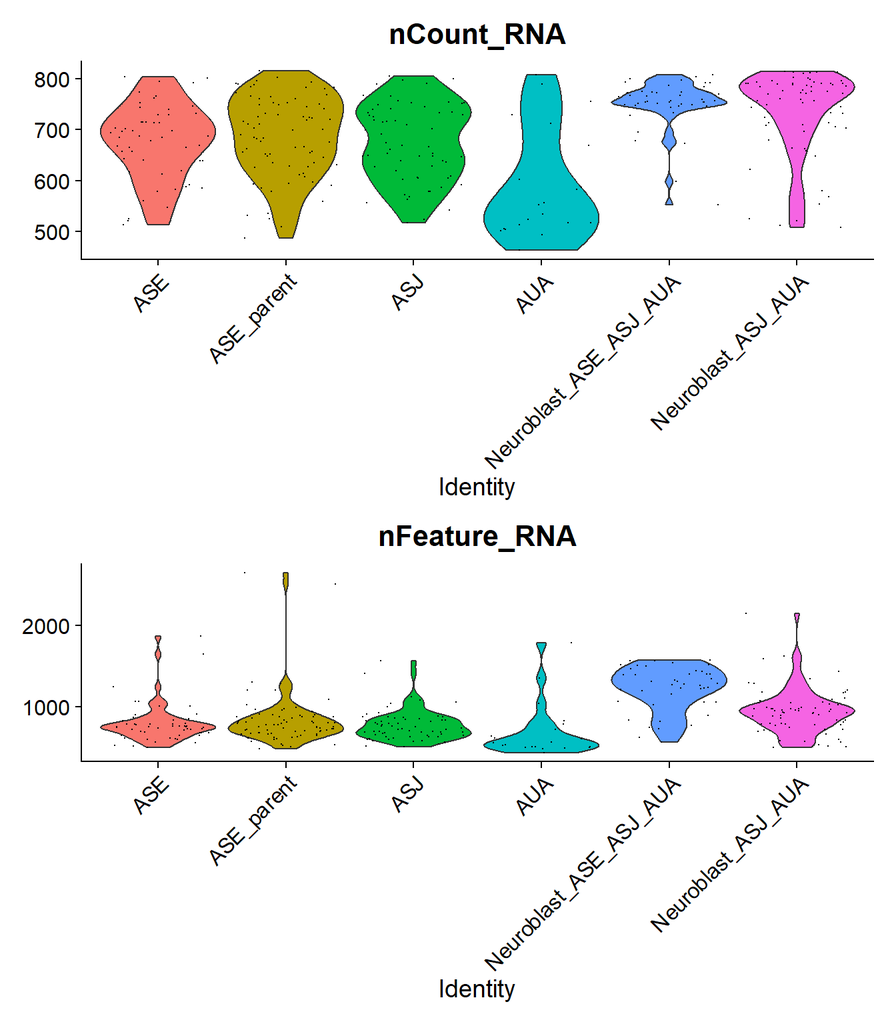

```r
VlnPlot(seu, c("nCount_RNA", "nFeature_RNA"), pt.size = 0.1, ncol = 1, group.by = "cell.subtype")
```

# Dimension reduction

UMAP can better preserve pairwise distance of cells than tSNE and can better separate cell populations than the first 2 PCs of PCA, so we will work with UMAP for visualization rather than tSNE or PCA.

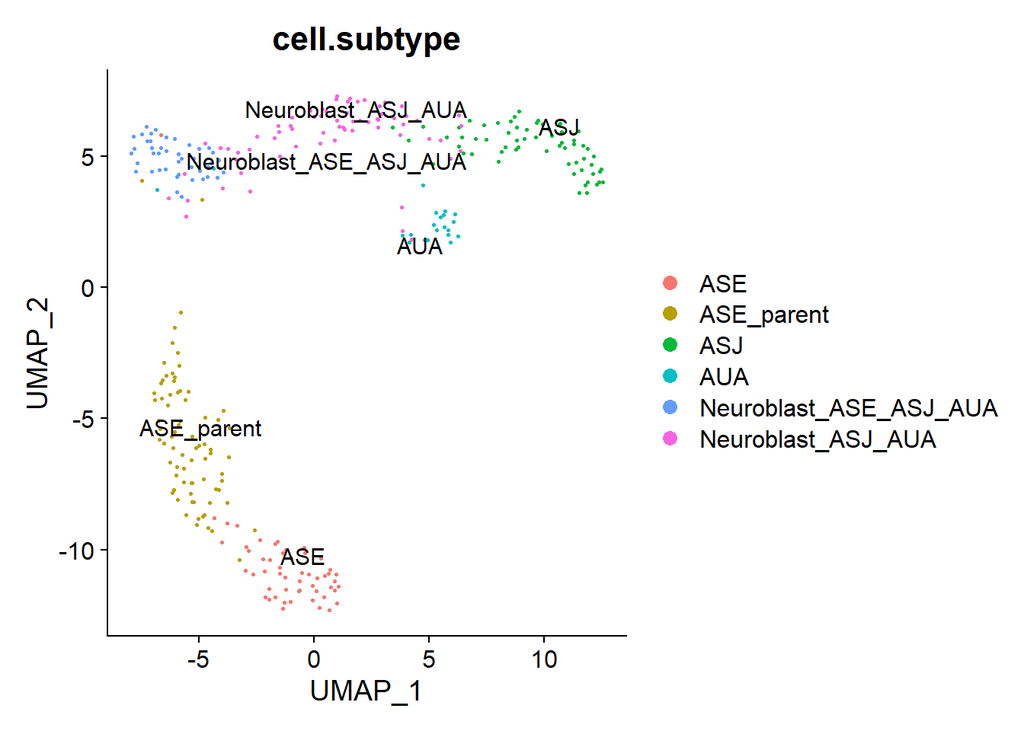

```r
seu <- RunPCA(seu)
seu <- RunUMAP(seu, n.neighbors = 10, dims = 1:50, spread = 2, min.dist = 0.3, seed.use = 654)
DimPlot(seu, reduction = "umap",
        group.by = "cell.subtype", pt.size = 0.5, label = TRUE, repel = TRUE)
```

```r
p_fpx$embryo.time <- p_fpx$embryo.time - min(p_fpx$embryo.time) + 1

cell_subtypes <- seu$cell.subtype

ctypes <- unique(cell_subtypes)

# define lineage cell sets
lins <- list(
  ASJ = cell_subtypes %in% ctypes[c(1, 4, 5)],
  AUA = cell_subtypes %in% ctypes[c(1, 5, 6)],
  ASE = cell_subtypes %in% ctypes[c(1, 2, 3)]
)
```

```r
prepare_and_interpolate <- function(X, p, lins, dim_red="ica", nc=8){
  mt <- multige_im(X = X, p = p, lineages = lins,
                   dim_red = dim_red, nc = nc,
                   formulas = c("X~s(embryo.time, bs='cr', k=6)"))

  # predict new data (in comp. space)
  ndat <- data.frame(embryo.time=seq(min(p$embryo.time),
                                     max(p$embryo.time), l=100))
  nX <- predict_mgeim(mt, ndat, as.c = T)
  interpGE <- predict_mgeim(mt, ndat)

  return(list(mt=mt, ndat=ndat, nX=nX, interpGE=interpGE))
}
```

# RAPToR

```r
# build train and test
p <- 0.8
rr <- split(1:length(cell_subtypes), cell_subtypes)
idx <- sort(as.numeric(unlist(sapply(rr, function(x) sample(x, length(x) * p)))))

pX_train <- pX[idx, ]
pX_test <- pX[-idx, ]

p_fpx_train <- p_fpx[idx, ]
p_fpx_test <- p_fpx[-idx, ]
```

First let’s build sets with 80/20 while keeping original proportions. In other words, stratified splitting of the dataset.

Original proportions :

```r
table(p_fpx$cell.subtype) / nrow(p_fpx)
```

```
##
##                    ASE             ASE_parent                    ASJ
##             0.16408669             0.23219814             0.19504644
##                    AUA Neuroblast_ASE_ASJ_AUA     Neuroblast_ASJ_AUA
##             0.06501548             0.13622291             0.20743034
```

Train proportions :

```r
table(p_fpx_train$cell.subtype) / nrow(p_fpx_train)
```

```
##
##                    ASE             ASE_parent                    ASJ
##              0.1640625              0.2343750              0.1953125
##                    AUA Neuroblast_ASE_ASJ_AUA     Neuroblast_ASJ_AUA
##              0.0625000              0.1367188              0.2070312
```

Test proportions :

```r
table(p_fpx_test$cell.subtype) / nrow(p_fpx_test)
```

```
##
##                    ASE             ASE_parent                    ASJ
##             0.16417910             0.22388060             0.19402985
##                    AUA Neuroblast_ASE_ASJ_AUA     Neuroblast_ASJ_AUA
##             0.07462687             0.13432836             0.20895522
```

We can see that the proportions are similar enough.

# Interpolation

```r
multige <- prepare_and_interpolate(pX, p_fpx, lins)
```

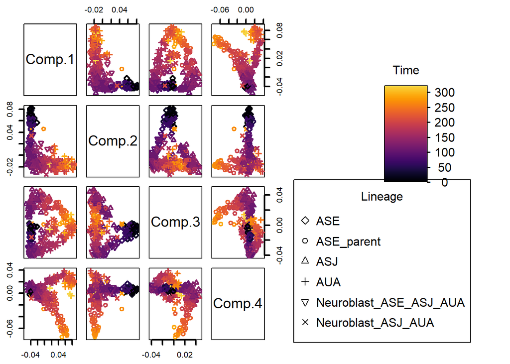

```r
cols <- viridisLite::inferno(max(p_fpx$embryo.time), end=.9)[p_fpx$embryo.time]
pchs <- as.numeric(as.factor(cell_subtypes))
pairs(multige$mt$dim_red$S[,1:4], col = cols, pch=pchs, lwd=2, labels=paste0("Comp.", 1:4), oma=c(2,2,2,25))
par(xpd = TRUE)
legend("bottomright", pch = as.numeric(as.factor(unique(cell_subtypes))),
       legend = c(levels(as.factor(cell_subtypes))), title="Lineage")
legend_image <- as.raster(matrix(viridisLite::inferno(max(p_fpx$embryo.time), end=.9), ncol=1))
text(x=.85, y=.85, labels = "Time")
rasterImage(legend_image, .8, .8, .9, .5)
rect(.8, .5, .9, .8)
labs <- seq(0, max(p_fpx$embryo.time),50)
ys <- seq(.5, .78, l=length(labs))
text(x=.903, y=ys, labels = "-")
text(x=.94, y=ys, labels = labs)
```

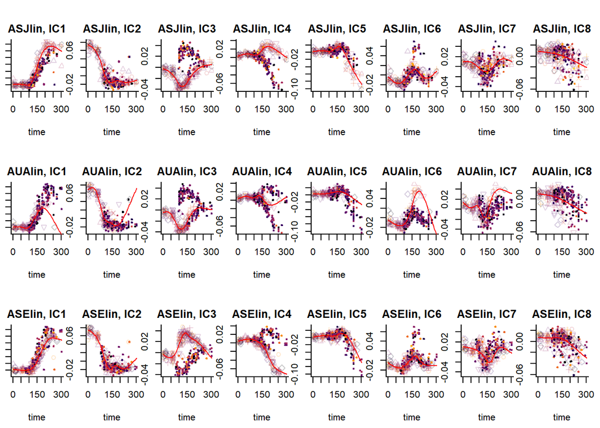

```r
plot_lineages(multige$mt, multige$ndat, multige$nX,
              p_fpx$embryo.time, p_fpx$cell.subtype, 1:8)
```

```r
res <- lapply(1:4, function(i){
  set.seed(i)
  p <- 0.8
  idx <- stratified_split(cell_subtypes, p)

  pX_train <- pX[, idx]
  pX_test <- pX[, -idx]

  p_fpx_train <- p_fpx[idx, ]
  p_fpx_test <- p_fpx[-idx, ]

  lins_train <- lapply(lins,'[', idx)
  lins_test <- lapply(lins,'[', -idx)

  multige <- prepare_and_interpolate(pX_train, p_fpx_train, lins_train)

  ae_s_train <- ale(samp = pX_train, multiref=list(interpGE=multige$interpGE, time=multige$ndat$embryo.time))

  ae_s_test <- ale(samp = pX_test, multiref=list(interpGE=multige$interpGE, time=multige$ndat$embryo.time))

  return(list(multige=multige,
              train=list(idx=idx,
                         ae_s=ae_s_train),
              test=list(idx=seq_along(cell_subtypes)[!seq_along(cell_subtypes) %in% idx],
                        ae_s=ae_s_test)))
})
```

# Staging

Predictions for train :

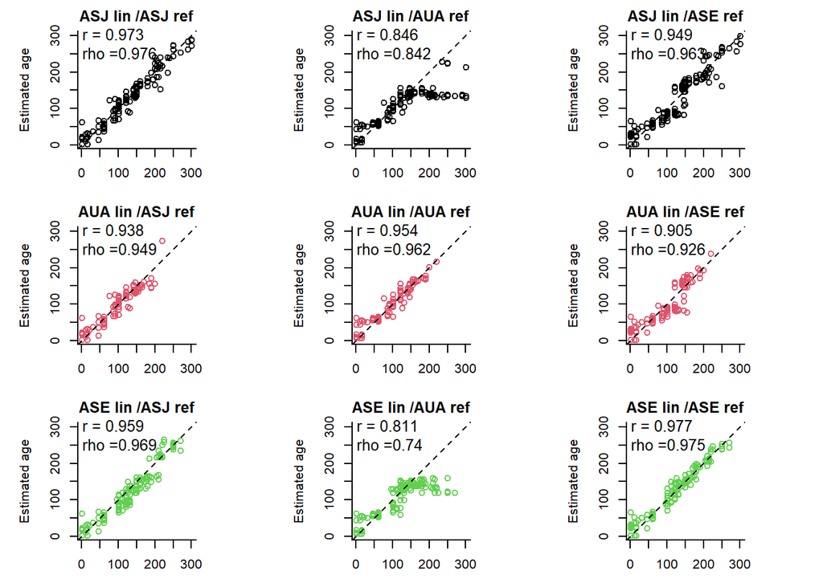

```r
plot_staged(res[[1]]$train$ae_s$ae.lin, p_fpx[res[[1]]$train$idx, ]$embryo.time,
            lapply(lins,'[', res[[1]]$train$idx))
```

Predictions for test :

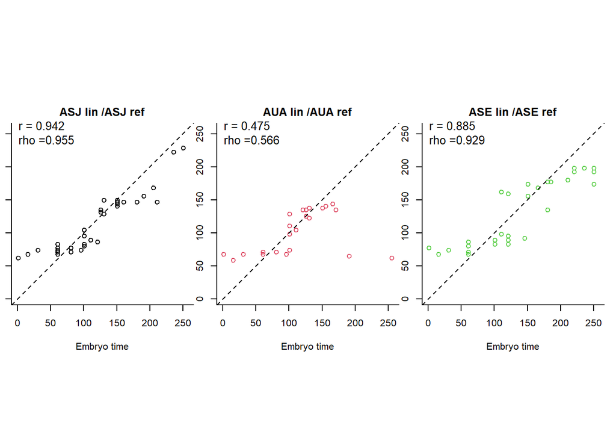

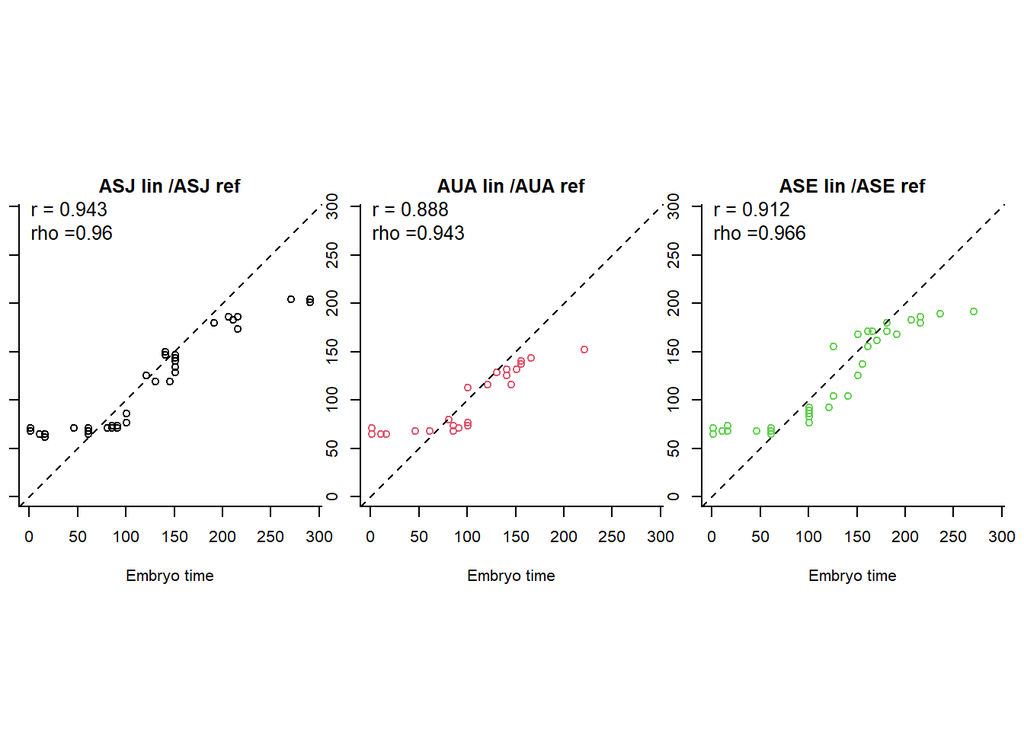

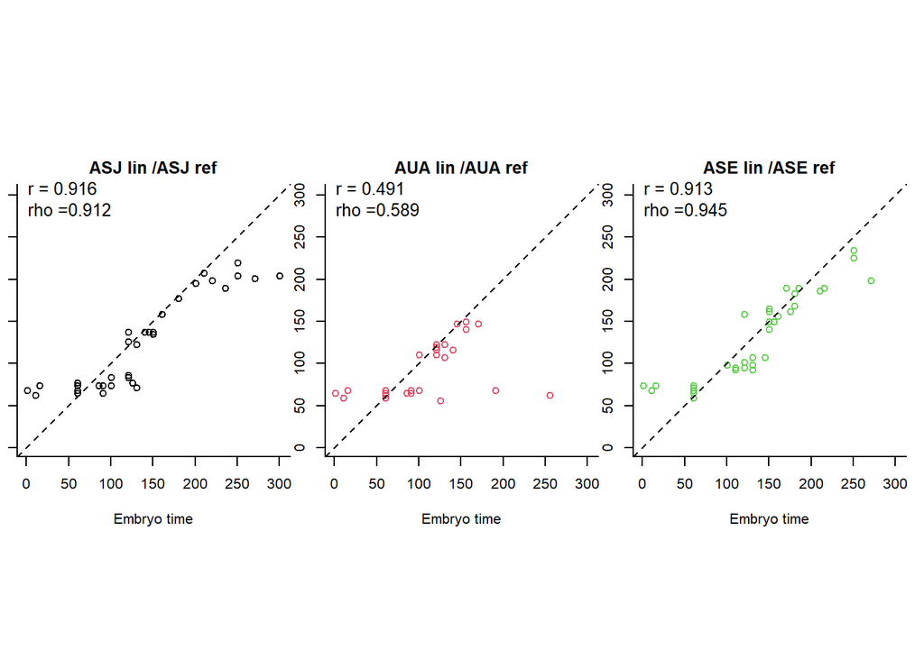

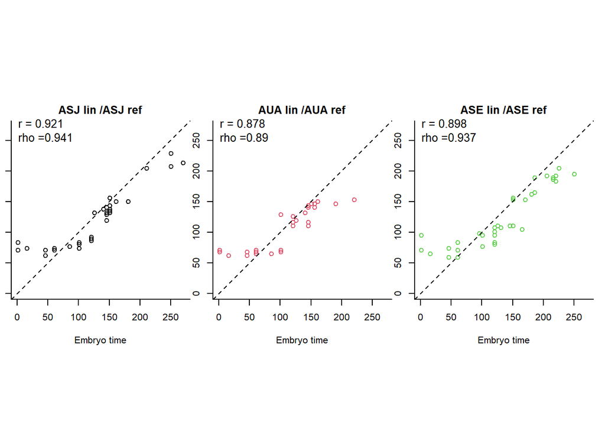

```r
lapply(seq_along(res), function(i){
  plot_staged(res[[i]]$test$ae_s$ae.lin, p_fpx[res[[i]]$test$idx, ]$embryo.time,
              lapply(lins,'[', res[[i]]$test$idx), mode="diag")
})
```

Results from 4 differents runs :

train pearson r :

```r
reduce_cor(res, lins, p_fpx, "train", "pearson")
```

```
##         ASJ     AUA     ASE
## ASJ 0.97150 0.86650 0.93175
## AUA 0.85425 0.93925 0.78675
## ASE 0.93675 0.83700 0.96550
```

train spearman rho :

```r
reduce_cor(res, lins, p_fpx, "train", "spearman")
```

```
##        ASJ     AUA     ASE
## ASJ 0.9760 0.91150 0.94525
## AUA 0.8715 0.94675 0.76775
## ASE 0.9570 0.89625 0.96550
```

test pearson r :

```r
reduce_cor(res, lins, p_fpx, "test", "pearson")
```

```
##        ASJ     AUA   ASE
## ASJ 0.9305 0.67325 0.864
## AUA 0.8420 0.68300 0.816
## ASE 0.8875 0.59550 0.902
```

test spearman rho :

```r
reduce_cor(res, lins, p_fpx, "test", "spearman")
```

```
##       ASJ     AUA     ASE
## ASJ 0.942 0.74250 0.89100
## AUA 0.885 0.74700 0.80175
## ASE 0.931 0.70825 0.94425
```

# Exploring lineage-inference from staging

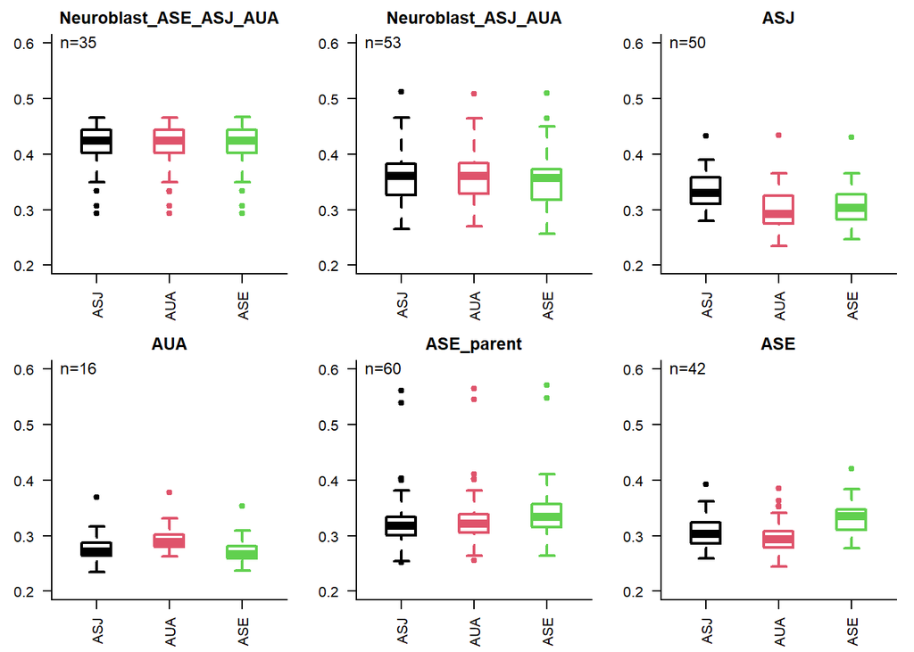

```r
plot_lineages_inference(res[[1]]$train$ae_s$ae.lin,
                        p_fpx[res[[1]]$train$idx, ]$cell.subtype,
                        ctypes[c(1,5,4,6,3,2)],
                        lapply(lins,'[', res[[1]]$train$idx))
```

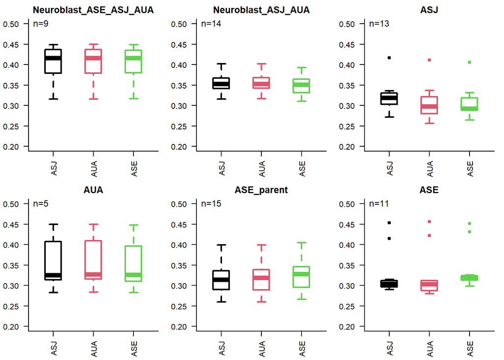

```r
plot_lineages_inference(res[[1]]$test$ae_s$ae.lin,
                        p_fpx[res[[1]]$test$idx, ]$cell.subtype,
                        ctypes[c(1,5,4,6,3,2)],
                        lapply(lins,'[', res[[1]]$test$idx))
```

Results from 4 different runs :

train :

```r
reduce_summary(res, lins, ctypes[c(1,5,4,6,3,2)], "train")
```

```
## $Neuroblast_ASE_ASJ_AUA
##               ASJ       AUA       ASE
## Min.    0.2966720 0.2967171 0.2966792
## 1st Qu. 0.3979221 0.3978937 0.3981990
## Median  0.4265461 0.4263954 0.4267157
## Mean    0.4139141 0.4139667 0.4141683
## 3rd Qu. 0.4448825 0.4451737 0.4453455
## Max.    0.4664155 0.4662187 0.4668002
##
## $Neuroblast_ASJ_AUA
##               ASJ       AUA       ASE
## Min.    0.2674512 0.2715207 0.2573056
## 1st Qu. 0.3375509 0.3385972 0.3273198
## Median  0.3659103 0.3667119 0.3577074
## Mean    0.3630825 0.3641393 0.3531029
## 3rd Qu. 0.3833994 0.3844320 0.3721522
## Max.    0.5105960 0.5096234 0.5084660
##
## $ASJ
##               ASJ       AUA       ASE
## Min.    0.2804025 0.2398395 0.2484176
## 1st Qu. 0.3118918 0.2731052 0.2843714
## Median  0.3296632 0.2907697 0.3024060
## Mean    0.3354180 0.2998544 0.3087495
## 3rd Qu. 0.3536097 0.3238235 0.3264141
## Max.    0.4307288 0.4283758 0.4239328
##
## $AUA
##               ASJ       AUA       ASE
## Min.    0.2476581 0.2714532 0.2459088
## 1st Qu. 0.2652365 0.2845102 0.2613754
## Median  0.2815087 0.2957145 0.2758359
## Mean    0.2937943 0.3096454 0.2885396
## 3rd Qu. 0.3027951 0.3171530 0.2981652
## Max.    0.4269813 0.4295721 0.4185546
##
## $ASE_parent
##               ASJ       AUA       ASE
## Min.    0.2529540 0.2548825 0.2671563
## 1st Qu. 0.3015077 0.3059859 0.3148568
## Median  0.3169750 0.3209666 0.3344488
## Mean    0.3243052 0.3276626 0.3410711
## 3rd Qu. 0.3333650 0.3394742 0.3577281
## Max.    0.5571650 0.5607695 0.5651817
##
## $ASE
##               ASJ       AUA       ASE
## Min.    0.2598609 0.2474016 0.2781533
## 1st Qu. 0.2903227 0.2778492 0.3167526
## Median  0.3046317 0.2922979 0.3351167
## Mean    0.3106801 0.3000648 0.3369336
## 3rd Qu. 0.3225121 0.3065537 0.3495438
## Max.    0.4478280 0.4431702 0.4480861
```

test :

```r
reduce_summary(res, lins, ctypes[c(1,5,4,6,3,2)], "test")
```

```
## $Neuroblast_ASE_ASJ_AUA
##               ASJ       AUA       ASE
## Min.    0.3160571 0.3158981 0.3163232
## 1st Qu. 0.3802691 0.3802768 0.3807952
## Median  0.4102127 0.4105660 0.4106891
## Mean    0.3975065 0.3976057 0.3977048
## 3rd Qu. 0.4267522 0.4266440 0.4262291
## Max.    0.4424162 0.4422849 0.4433369
##
## $Neuroblast_ASJ_AUA
##               ASJ       AUA       ASE
## Min.    0.2734187 0.2739780 0.2660237
## 1st Qu. 0.3192639 0.3195874 0.3149106
## Median  0.3409215 0.3404499 0.3392749
## Mean    0.3432993 0.3432421 0.3411355
## 3rd Qu. 0.3625432 0.3623881 0.3615092
## Max.    0.4228305 0.4235052 0.4203749
##
## $ASJ
##               ASJ       AUA       ASE
## Min.    0.2780432 0.2589670 0.2703971
## 1st Qu. 0.2990364 0.2796345 0.2845938
## Median  0.3195410 0.3025629 0.3012178
## Mean    0.3196893 0.3046732 0.3060147
## 3rd Qu. 0.3344596 0.3213396 0.3181026
## Max.    0.3848220 0.3791822 0.3741973
##
## $AUA
##               ASJ       AUA       ASE
## Min.    0.2498475 0.2477701 0.2488666
## 1st Qu. 0.2783740 0.2798580 0.2754537
## Median  0.2960158 0.2960099 0.2956015
## Mean    0.3136890 0.3133947 0.3105550
## 3rd Qu. 0.3475365 0.3477511 0.3409832
## Max.    0.3966710 0.3955843 0.3918701
##
## $ASE_parent
##               ASJ       AUA       ASE
## Min.    0.2582785 0.2604826 0.2643190
## 1st Qu. 0.2879873 0.2893752 0.2956637
## Median  0.3124614 0.3151709 0.3219705
## Mean    0.3217871 0.3236391 0.3293034
## 3rd Qu. 0.3356205 0.3383014 0.3440943
## Max.    0.4728405 0.4738142 0.4762055
##
## $ASE
##               ASJ       AUA       ASE
## Min.    0.2723816 0.2647335 0.2804365
## 1st Qu. 0.2887618 0.2830387 0.3012046
## Median  0.3010242 0.2979255 0.3130405
## Mean    0.3087955 0.3049399 0.3205469
## 3rd Qu. 0.3142811 0.3104746 0.3259344
## Max.    0.3874210 0.3886532 0.3982994
```

# Normalization

Predictions for train :

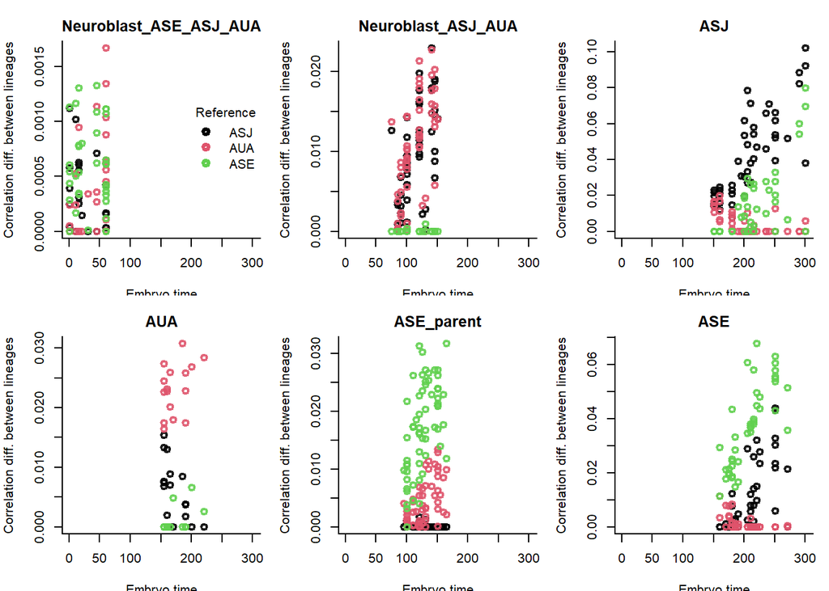

```r
plot_lineage_inference_norm(res[[1]]$train$ae_s$ae.lin,
                            p_fpx[res[[1]]$train$idx, ]$cell.subtype,
                            ctypes[c(1,5,4,6,3,2)],
                            p_fpx[res[[1]]$train$idx, ]$embryo.time,
                            lapply(lins,'[', res[[1]]$train$idx))
```

Predictions for test :

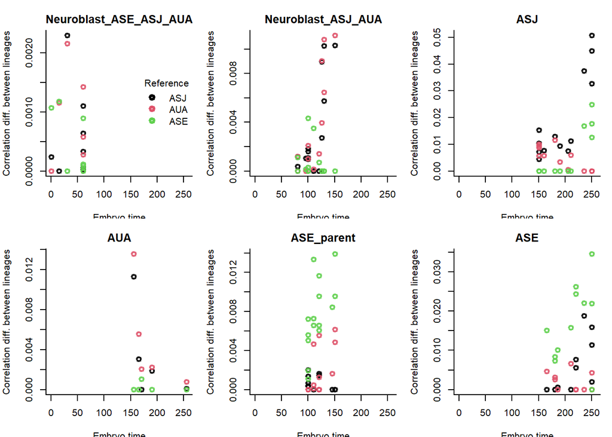

```r
plot_lineage_inference_norm(res[[1]]$test$ae_s$ae.lin,
                            p_fpx[res[[1]]$test$idx, ]$cell.subtype,
                            ctypes[c(1,5,4,6,3,2)],
                            p_fpx[res[[1]]$test$idx, ]$embryo.time,
                            lapply(lins,'[', res[[1]]$test$idx))
```

Results from 4 different runs :

train :

```r
reduce_lineage_inference(res, p_fpx, "train")
```

```
##                         predicted
## known                           ASE        ASJ        AUA
##   ASE                    1.00000000 0.00000000 0.00000000
##   ASE_parent             0.96666667 0.00000000 0.03333333
##   ASJ                    0.00000000 0.92000000 0.08000000
##   AUA                    0.00000000 0.00000000 1.00000000
##   Neuroblast_ASE_ASJ_AUA 0.62857143 0.05714286 0.31428571
##   Neuroblast_ASJ_AUA     0.00000000 0.16981132 0.83018868
```

test :

```r
reduce_lineage_inference(res, p_fpx, "test")
```

```
##                         predicted
## known                           ASE        ASJ        AUA
##   ASE                    0.90909091 0.00000000 0.09090909
##   ASE_parent             1.00000000 0.00000000 0.00000000
##   ASJ                    0.00000000 0.84615385 0.15384615
##   AUA                    0.00000000 0.00000000 1.00000000
##   Neuroblast_ASE_ASJ_AUA 0.44444444 0.22222222 0.33333333
##   Neuroblast_ASJ_AUA     0.21428571 0.21428571 0.57142857
```